# Pendugaan Parameter, Diagnostik Model, dan Peramalan

# Metode Peramalan Deret Waktu

## Tugas Individu

### Muhammad Haikal Rasyadan | G1401221026 | P2

## Library / Packages

```r
library(ggplot2)
library(tsibble)
library(tseries)
library(MASS)
library(forecast)
library(TSA)
library(TTR)
library(aTSA)
library(graphics)
library(readxl)
```

# Data

```r
data <- read_excel("/Users/user/Downloads/Documents/MPDW 💹/mpdw_pemulusan_individu.xlsx")
data.ts <- ts(data$Penumpang)
str(data.ts)
```

```
##  Time-Series [1:106] from 1 to 106: 6458 7493 6304 6506 6283 ...
```

# Eksplorasi Data

## Plot Data Penuh

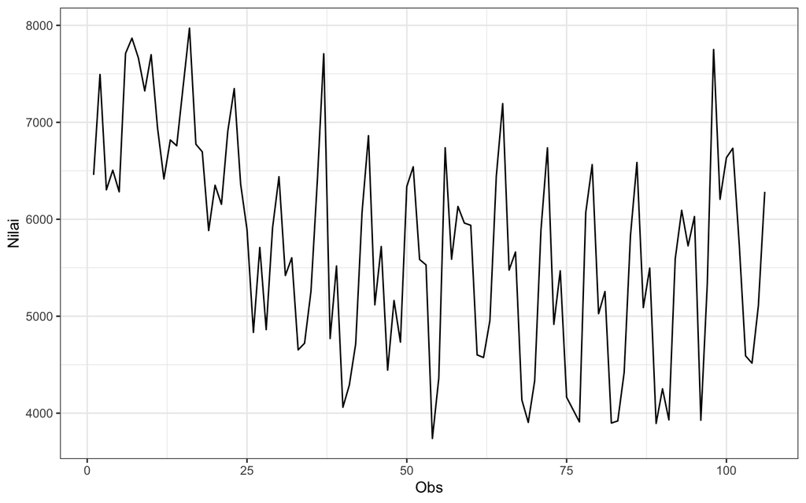

```r
plot_data <- data.ts |> as_tsibble() |>
  ggplot(aes(x = index, y = value)) + geom_line() + theme_bw() +
  xlab("Obs") + ylab("Nilai")
plot_data
```

```r
mean(data.ts)
```

```
## [1] 5719.698
```

Plot deret waktu di atas menunjukkan bahwa data cenderung **tidak stasioner dalam rataan**, ditandai dengan data yang tidak menyebar di sekitar nilai tengahnya (5719.698). Namun, plot tersebut menunjukan indikasi data **stasioner dalam ragam**, ditandai dengan lebar pita yang cenderung sama.

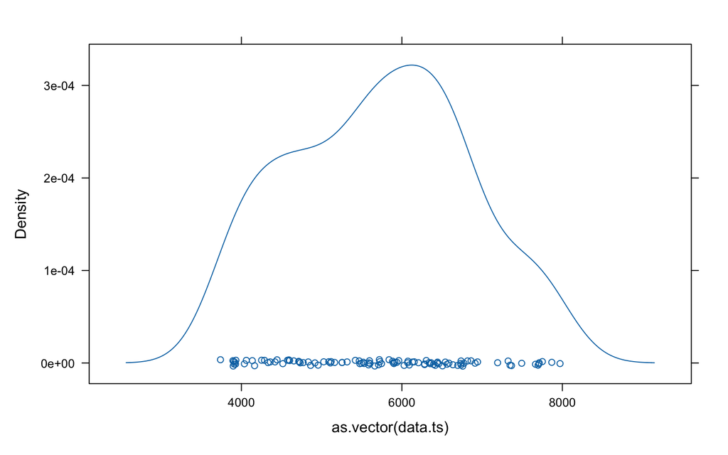

```r
lattice::densityplot(as.vector(data.ts))
```

## Plot Data Latih

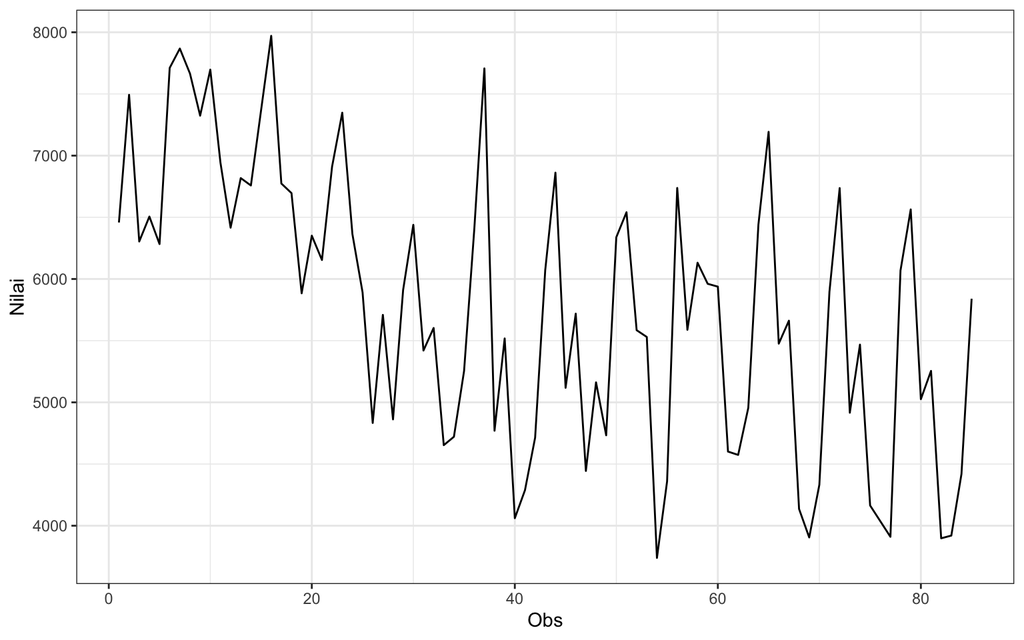

```r
train <- data.ts[1:85]
train.ts <- ts(train)
plot_train <- train.ts |> as_tsibble() |>
  ggplot(aes(x = index, y = value)) + geom_line() + theme_bw() +
  xlab("Obs") + ylab("Nilai")
plot_train
```

```r
mean(train.ts)
```

```
## [1] 5773.929
```

## Plot Data Uji

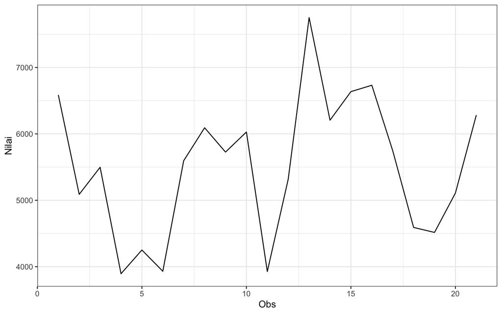

```r
test <- data.ts[86:106]
test.ts <- ts(test)
plot_test <- test.ts |> as_tsibble() |>
  ggplot(aes(x = index, y = value)) + geom_line() + theme_bw() +
  xlab("Obs") + ylab("Nilai")
plot_test
```

```r
mean(test.ts)
```

```
## [1] 5500.19
```

# Uji Stasioneritas Data

## Plot ACF

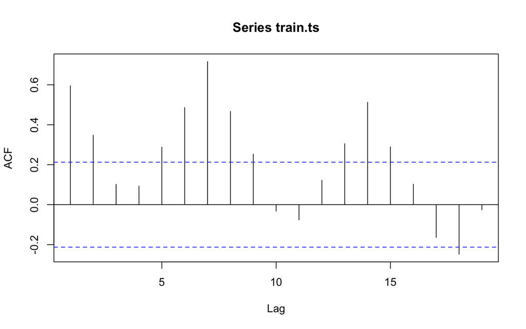

```r
acf(train.ts)
```

## Uji ADF

```r
tseries::adf.test(train.ts)
```

```
##
##  Augmented Dickey-Fuller Test
##
## data:  train.ts
## Dickey-Fuller = -3.8923, Lag order = 4, p-value = 0.0185
## alternative hypothesis: stationary
```

$H_0$ : Data tidak stasioner dalam rataan

$H_1$ : Data stasioner dalam rataan

Berdasarkan uji ADF tersebut, didapat *p-value* sebesar 0.0185 yang lebih kecil dari taraf nyata 5% sehingga tolak $H_0$ dan menandakan bahwa data **stasioner dalam rataan**. Hal ini tidak sesuai dengan hasil plot ACF, dapat disebabkan karena plot ACF cenderung lebih subjektif sehingga mungkin saja terdapat perbedaan antara hasil eksplorasi dengan uji formalnya.

## Plot Box-Cox

```r
index <- seq(1:85)
bc = boxcox(train.ts~index, lambda = seq(-0.5,2.5,by=0.1))
```

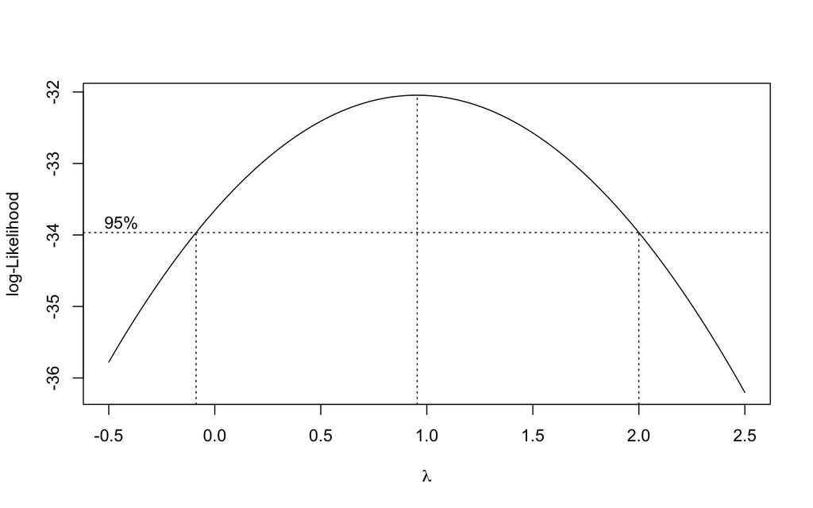

```r
#Nilai Rounded Lambda
lambda <- bc$x[which.max(bc$y)]
lambda
```

```
## [1] 0.9545455
```

```r
#SK
bc$x[bc$y > max(bc$y) - 1/2 * qchisq(.95,1)]
```

```
##  [1] -0.07575758 -0.04545455 -0.01515152  0.01515152  0.04545455  0.07575758
##  [7]  0.10606061  0.13636364  0.16666667  0.19696970  0.22727273  0.25757576
## [13]  0.28787879  0.31818182  0.34848485  0.37878788  0.40909091  0.43939394
## [19]  0.46969697  0.50000000  0.53030303  0.56060606  0.59090909  0.62121212
## [25]  0.65151515  0.68181818  0.71212121  0.74242424  0.77272727  0.80303030
## [31]  0.83333333  0.86363636  0.89393939  0.92424242  0.95454545  0.98484848
## [37]  1.01515152  1.04545455  1.07575758  1.10606061  1.13636364  1.16666667
## [43]  1.19696970  1.22727273  1.25757576  1.28787879  1.31818182  1.34848485
## [49]  1.37878788  1.40909091  1.43939394  1.46969697  1.50000000  1.53030303
## [55]  1.56060606  1.59090909  1.62121212  1.65151515  1.68181818  1.71212121
## [61]  1.74242424  1.77272727  1.80303030  1.83333333  1.86363636  1.89393939
## [67]  1.92424242  1.95454545  1.98484848
```

Gambar di atas menunjukkan nilai *rounded value* ($\lambda$) optimum sebesar **0.95** dan pada selang kepercayaan 95% nilai memiliki batas bawah **-0.076** dan batas atas **1.985**. Selang tersebut memuat nilai satu sehingga dapat dikatakan bahwa data keseluruhan **stasioner dalam ragam**.

Dikarenakan data train telah **stasioner dalam rataan maupun ragam**, maka **tidak diperlukan penanganan ketidakstasioneran** pada data sehingga dapat dilanjutkan dengan identifikasi model.

# Identifikasi Model

## Plot ACF

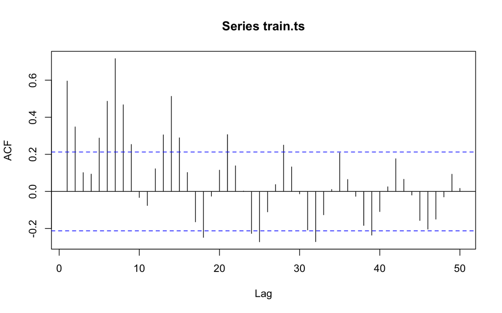

```r
acf(train.ts, 50)
```

## Plot PACF

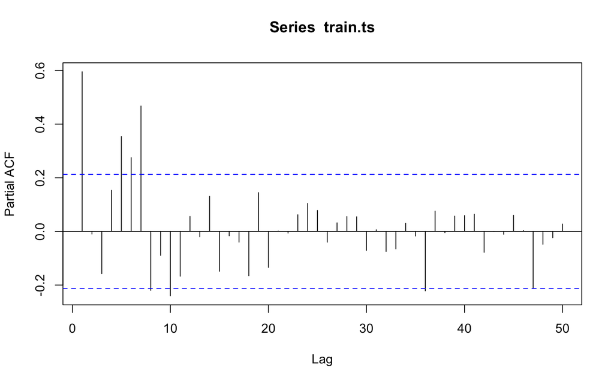

```r
pacf(train.ts, 50)
```

## Plot EACF

```r
eacf(train.ts)
```

```
## AR/MA
##   0 1 2 3 4 5 6 7 8 9 10 11 12 13
## 0 x x o o x x x x x o o  o  x  x
## 1 o x x o o o x o x o o  o  o  x
## 2 o o o o o o x o x o o  o  o  x
## 3 x x o o o o x x x o o  o  o  x
## 4 x x o o o o x o x o o  o  o  x
## 5 x x o o o o x o o o o  o  o  o
## 6 x o x o x x x o o o o  o  o  o
## 7 o o x x o o o o o o o  o  o  o
```

Identifikasi model menggunakan plot EACF dilakukan dengan melihat ujung segitiga pada pola segitiga nol. Dalam hal ini model tentatif yang terbentuk pada plot EACF adalah ARIMA(2,0,1), ARIMA(1,0,9), dan ARIMA(5,0,7).

Sehingga didapatkan 5 model tentatif yaitu, ARIMA(1,0,2), ARIMA(1,0,0), ARIMA(2,0,1), ARIMA(1,0,9), dan ARIMA(5,0,7).

# Pendugaan Parameter Model Tentatif

## ARIMA(1,0,2)

```r
model1.da=Arima(train.ts, order=c(1,0,2),method="ML")
summary(model1.da) #AIC = 1402.82
```

```
## Series: train.ts
## ARIMA(1,0,2) with non-zero mean
##
## Coefficients:
##          ar1     ma1     ma2       mean
##       0.3001  0.3013  0.3015  5787.7633
## s.e.  0.2387  0.2423  0.1224   214.1793
##
## sigma^2 = 797963:  log likelihood = -696.41
## AIC=1402.82   AICc=1403.58   BIC=1415.03
##
## Training set error measures:
##                     ME     RMSE      MAE       MPE     MAPE      MASE
## Training set -3.934852 872.0157 717.1885 -2.549111 13.12003 0.8937459
##                     ACF1
## Training set 0.009088307
```

```r
lmtest::coeftest(model1.da)
```

```
##
## z test of coefficients:
##
##             Estimate Std. Error z value Pr(>|z|)
## ar1          0.30011    0.23874  1.2571  0.20872
## ma1          0.30125    0.24227  1.2434  0.21371
## ma2          0.30150    0.12238  2.4636  0.01375 *
## intercept 5787.76328  214.17928 27.0230  < 2e-16 ***
## ---
## Signif. codes:  0 '***' 0.001 '**' 0.01 '*' 0.05 '.' 0.1 ' ' 1
```

## ARIMA(1,0,0)

```r
model2.da=Arima(train.ts, order=c(1,0,0),method="ML")
summary(model2.da) #AIC = 1402.67
```

```
## Series: train.ts
## ARIMA(1,0,0) with non-zero mean
##
## Coefficients:
##          ar1       mean
##       0.5909  5786.0727
## s.e.  0.0862   232.8092
##
## sigma^2 = 816105:  log likelihood = -698.34
## AIC=1402.67   AICc=1402.97   BIC=1410
##
## Training set error measures:
##                     ME     RMSE      MAE       MPE     MAPE      MASE
## Training set -6.120443 892.6941 736.3089 -2.734729 13.56108 0.9175733
##                     ACF1
## Training set 0.007854049
```

```r
lmtest::coeftest(model2.da)
```

```
##
## z test of coefficients:
##
##             Estimate Std. Error z value  Pr(>|z|)
## ar1       5.9092e-01 8.6163e-02  6.8582 6.972e-12 ***
## intercept 5.7861e+03 2.3281e+02 24.8533 < 2.2e-16 ***
## ---
## Signif. codes:  0 '***' 0.001 '**' 0.01 '*' 0.05 '.' 0.1 ' ' 1
```

## ARIMA(2,0,1)

```r
model3.da=Arima(train.ts, order=c(2,0,1),method="ML")
summary(model3.da) #AIC = 1406.32
```

```
## Series: train.ts
## ARIMA(2,0,1) with non-zero mean
##
## Coefficients:
##          ar1     ar2     ma1      mean
##       0.0797  0.3397  0.4792  5788.046
## s.e.  0.3898  0.2375  0.3861   241.633
##
## sigma^2 = 832679:  log likelihood = -698.16
## AIC=1406.32   AICc=1407.08   BIC=1418.53
##
## Training set error measures:
##                     ME     RMSE      MAE       MPE     MAPE      MASE
## Training set -7.402085 890.7826 731.3066 -2.739939 13.43969 0.9113395
##                    ACF1
## Training set 0.04773555
```

```r
lmtest::coeftest(model3.da)
```

```
##
## z test of coefficients:
##
##             Estimate Std. Error z value Pr(>|z|)
## ar1       7.9701e-02 3.8982e-01  0.2045   0.8380
## ar2       3.3971e-01 2.3750e-01  1.4304   0.1526
## ma1       4.7916e-01 3.8615e-01  1.2409   0.2147
## intercept 5.7880e+03 2.4163e+02 23.9539   <2e-16 ***
## ---
## Signif. codes:  0 '***' 0.001 '**' 0.01 '*' 0.05 '.' 0.1 ' ' 1
```

## ARIMA(1,0,9)

```r
model4.da=Arima(train.ts, order=c(1,0,9),method="ML")
summary(model4.da) #AIC = 1384.19
```

```
## Series: train.ts
## ARIMA(1,0,9) with non-zero mean
##
## Coefficients:
##           ar1     ma1     ma2     ma3     ma4     ma5     ma6     ma7     ma8
##       -0.4909  0.9952  0.5774  0.2726  0.2612  0.2726  0.4476  0.8169  0.6029
## s.e.   0.2108  0.2249  0.1746  0.1164  0.1465  0.1674  0.1826  0.1819  0.1872
##          ma9       mean
##       0.4312  5752.9417
## s.e.  0.1310   278.6402
##
## sigma^2 = 565776:  log likelihood = -680.09
## AIC=1384.19   AICc=1388.52   BIC=1413.5
##
## Training set error measures:
##                    ME     RMSE      MAE       MPE     MAPE      MASE
## Training set -5.84887 701.8248 570.7303 -1.976612 10.41216 0.7112326
##                     ACF1
## Training set -0.01579212
```

```r
lmtest::coeftest(model4.da)
```

```
##
## z test of coefficients:
##
##             Estimate Std. Error z value  Pr(>|z|)
## ar1         -0.49093    0.21079 -2.3290 0.0198589 *
## ma1          0.99515    0.22487  4.4254 9.628e-06 ***
## ma2          0.57740    0.17461  3.3069 0.0009434 ***
## ma3          0.27262    0.11642  2.3417 0.0191979 *
## ma4          0.26120    0.14648  1.7832 0.0745567 .
## ma5          0.27257    0.16742  1.6281 0.1035033
## ma6          0.44757    0.18257  2.4515 0.0142262 *
## ma7          0.81689    0.18189  4.4912 7.083e-06 ***
## ma8          0.60295    0.18720  3.2209 0.0012780 **
## ma9          0.43120    0.13098  3.2921 0.0009945 ***
## intercept 5752.94170  278.64024 20.6465 < 2.2e-16 ***
## ---
## Signif. codes:  0 '***' 0.001 '**' 0.01 '*' 0.05 '.' 0.1 ' ' 1
```

## ARIMA(5,0,7)

```r
model5.da=Arima(train.ts, order=c(5,0,7),method="ML")
summary(model5.da) #AIC = 1354.86
```

```
## Series: train.ts
## ARIMA(5,0,7) with non-zero mean
##
## Coefficients:
##          ar1     ar2      ar3      ar4     ar5      ma1     ma2     ma3     ma4
##       0.5149  0.6325  -0.6249  -0.3472  0.7595  -0.3040  -0.737  0.3928  0.5447
## s.e.  0.0833  0.0954   0.0977   0.0884  0.0785   0.1489   0.123  0.1148  0.1349
##           ma5     ma6     ma7       mean
##       -0.8198  0.0526  0.7249  5882.5989
## s.e.   0.0990  0.1368  0.1289   556.9904
##
## sigma^2 = 343765:  log likelihood = -663.43
## AIC=1354.86   AICc=1360.86   BIC=1389.05
##
## Training set error measures:
##                     ME     RMSE      MAE       MPE     MAPE      MASE
## Training set -48.59178 539.6191 418.9178 -1.743987 7.407038 0.5220469
##                    ACF1
## Training set 0.06058544
```

```r
lmtest::coeftest(model5.da)
```

```
##
## z test of coefficients:
##
##              Estimate  Std. Error z value  Pr(>|z|)
## ar1          0.514925    0.083295  6.1820 6.331e-10 ***
## ar2          0.632494    0.095408  6.6293 3.372e-11 ***
## ar3         -0.624896    0.097691 -6.3967 1.588e-10 ***
## ar4         -0.347226    0.088396 -3.9281 8.562e-05 ***
## ar5          0.759534    0.078452  9.6815 < 2.2e-16 ***
## ma1         -0.304027    0.148933 -2.0414 0.0412143 *
## ma2         -0.737049    0.122987 -5.9929 2.061e-09 ***
## ma3          0.392840    0.114843  3.4207 0.0006247 ***
## ma4          0.544749    0.134853  4.0396 5.355e-05 ***
## ma5         -0.819813    0.099002 -8.2808 < 2.2e-16 ***
## ma6          0.052624    0.136804  0.3847 0.7004845
## ma7          0.724909    0.128900  5.6238 1.868e-08 ***
## intercept 5882.598920  556.990394 10.5614 < 2.2e-16 ***
## ---
## Signif. codes:  0 '***' 0.001 '**' 0.01 '*' 0.05 '.' 0.1 ' ' 1
```

Berdasarkan pendugaan parameter di atas, nilai **AIC terkecil** dimiliki oleh model ARIMA(5,0,7) dan parameter model ARIMA(5,0,7) juga **seluruhnya signifikan kecuali ma6** sehingga model yang dipilih adalah model **ARIMA(5,0,7)**.

# Analisis Sisaan

## Eksplorasi Sisaan

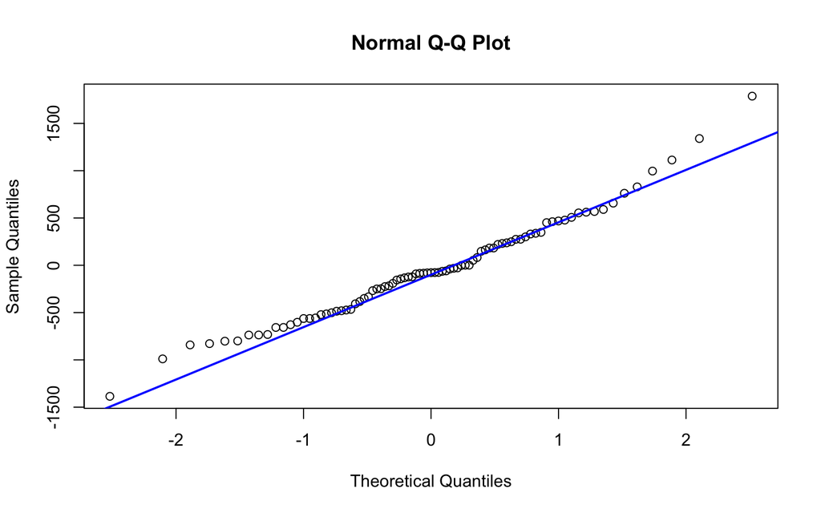

```r
sisaan.da <- model5.da$residuals
qqnorm(sisaan.da)
qqline(sisaan.da, col = "blue", lwd = 2)
```

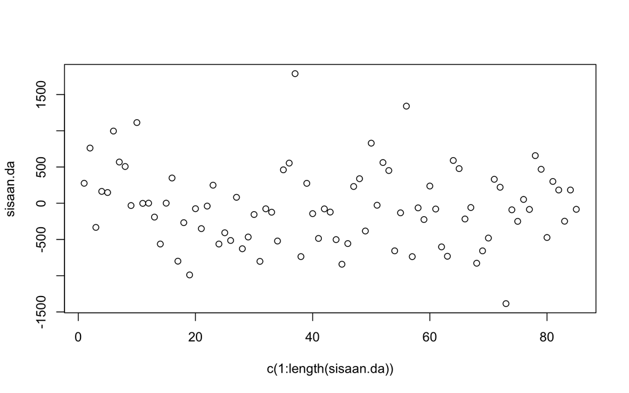

```r
plot(c(1:length(sisaan.da)),sisaan.da)
```

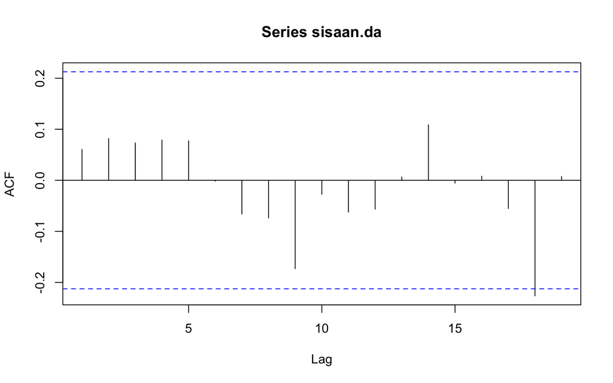

```r
acf(sisaan.da)
```

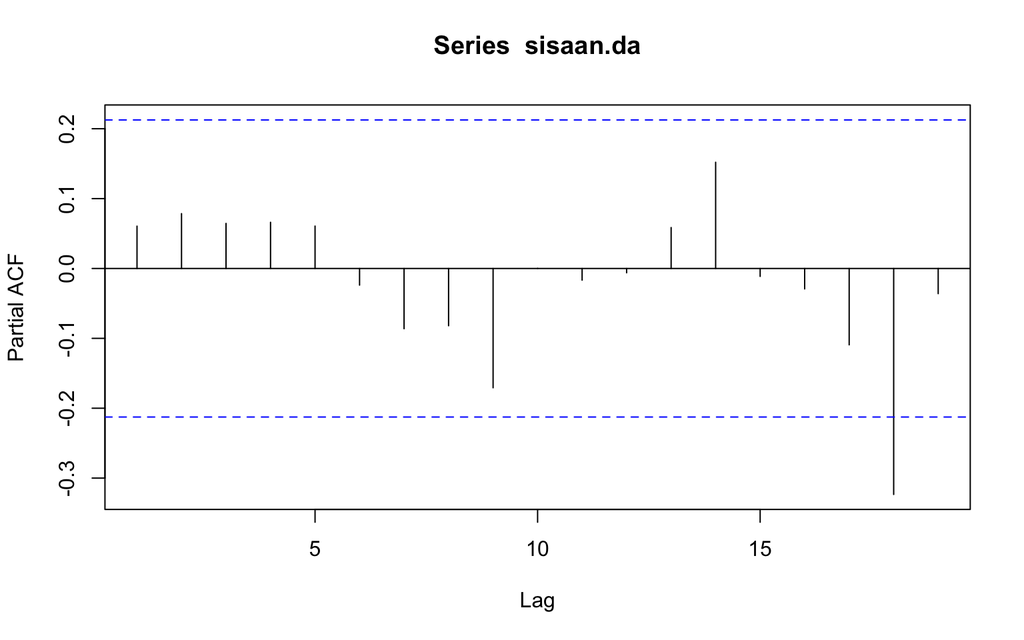

```r
pacf(sisaan.da)
```

Berdasarkan plot kuantil-kuantil normal, secara eksplorasi ditunjukkan sisaan tidak menyebar normal ditandai dengan titik titik yang cenderung tidak mengikuti garis $45^{\circ}$. Selain itu, Plot ACF dan PACF sisaan ARIMA(5,0,7) signifikan pada lag ke 18 yang menandakan sisaan tidak saling bebas. Namun, dapat dilihat lebar pita sisaan yang cenderung sama menandakan bahwa sisaan memiliki ragam yang homogen. Kondisi ini akan diuji lebih lanjut dengan uji formal.

## Uji Formal Sisaan

### Asumsi Normalitas

```r
ks.test(sisaan.da,"pnorm")
```

```
##
##  Exact one-sample Kolmogorov-Smirnov test
##
## data:  sisaan.da
## D = 0.58824, p-value = 9.992e-16
## alternative hypothesis: two-sided
```

$H_0$ : Sisaan menyebar normal

$H_1$ : Sisaan tidak menyebar normal

Berdasarkan uji KS tersebut, didapat *p-value* sebesar 0.0000000000000009992 yang lebih kecil dari taraf nyata 5% sehingga tolak $H_0$ dan menandakan bahwa sisaan tidak menyebar normal. Menandakan bahwa **asumsi tidak terpenuhi**. Hal ini sesuai dengan hasil eksplorasi menggunakan plot kuantil-kuantil normal.

### Asumsi Sisaan Saling Bebas

```r
Box.test(sisaan.da, type = "Ljung")
```

```
##
##  Box-Ljung test
##
## data:  sisaan.da
## X-squared = 0.32314, df = 1, p-value = 0.5697
```

$H_0$ : Sisaan saling bebas

$H_1$ : Sisaan tidak tidak saling bebas

Berdasarkan uji Ljung-Box tersebut, didapat *p-value* sebesar 0.5697 yang lebih besar dari taraf nyata 5% sehingga tak tolak $H_0$ dan menandakan bahwa sisaan saling bebas. Menandakan bahwa **asumsi terpenuhi**. Hal ini berbeda dengan eksplorasi.

### Asumsi Heteroskedastisitas

```r
Box.test((sisaan.da)^2, type = "Ljung")
```

```
##
##  Box-Ljung test
##
## data:  (sisaan.da)^2
## X-squared = 0.057595, df = 1, p-value = 0.8103
```

$H_0$ : Ragam sisaan homogen

$H_1$ : Ragam sisaan tidak homogen

Berdasarkan uji Ljung-Box terhadap sisaan kuadrat tersebut, didapat *p-value* sebesar 0.8103 yang lebih besar dari taraf nyata 5% sehingga tak tolak $H_0$ dan menandakan bahwa ragam sisaan homogen. Menandakan bahwa **asumsi terpenuhi**. Hal ini sesuai dengan hasil eksplorasi.

### Asumsi Nilai Tengah Sisaan = 0

```r
t.test(sisaan.da, mu = 0, conf.level = 0.95)
```

```
##
##  One Sample t-test
##
## data:  sisaan.da
## t = -0.82867, df = 84, p-value = 0.4096
## alternative hypothesis: true mean is not equal to 0
## 95 percent confidence interval:
##  -165.20003   68.01647
## sample estimates:
## mean of x
## -48.59178
```

$H_0$ : nilai tengah sisaan sama dengan 0

$H_1$ : nilai tengah sisaan tidak sama dengan 0

Berdasarkan uji-ttersebut, didapat *p-value* sebesar 0.4096 yang lebih besar dari taraf nyata 5% sehingga tak tolak $H_0$ dan menandakan bahwa nilai tengah sisaan sama dengan nol. Menandakan bahwa **asumsi terpenuhi**. Hal ini berbeda dengan eksplorasi.

# Overfitting

Tahapan selanjutnya adalah *overfitting* dilakukan dengan menaikkan orde AR(p) dan MA(q) dari model ARIMA(5,0,7) untuk melihat apakah terdapat model lain yang lebih baik dari model saat ini. Kandidat model *overfitting* adalah ARIMA(6,0,7) dan ARIMA(5,0,8).

```r
model5a.da=Arima(train.ts, order=c(6,0,7),method="ML")
summary(model5a.da) #AIC = 1349.12
```

```
## Series: train.ts
## ARIMA(6,0,7) with non-zero mean
##
## Coefficients:
##          ar1     ar2      ar3      ar4     ar5     ar6     ma1      ma2     ma3
##       0.1490  0.7872  -0.4853  -0.6664  0.6660  0.3461  0.0857  -0.6147  0.4950
## s.e.  0.2524  0.1577   0.1583   0.1730  0.1366  0.2342  0.2492   0.1684  0.2025
##          ma4      ma5      ma6     ma7       mean
##       1.1126  -0.3067  -0.3186  0.3226  5722.9365
## s.e.  0.1273   0.2410   0.2128  0.1402   413.6474
##
## sigma^2 = 316176:  log likelihood = -659.56
## AIC=1349.12   AICc=1356.07   BIC=1385.76
##
## Training set error measures:
##                     ME     RMSE      MAE       MPE     MAPE      MASE
## Training set -20.08222 513.9066 410.8598 -1.447393 7.399545 0.5120053
##                     ACF1
## Training set -0.01194409
```

```r
lmtest::coeftest(model5a.da)
```

```
##
## z test of coefficients:
##
##              Estimate  Std. Error z value  Pr(>|z|)
## ar1          0.149041    0.252368  0.5906 0.5548082
## ar2          0.787244    0.157724  4.9913 5.998e-07 ***
## ar3         -0.485256    0.158342 -3.0646 0.0021795 **
## ar4         -0.666432    0.173004 -3.8521 0.0001171 ***
## ar5          0.665957    0.136592  4.8755 1.085e-06 ***
## ar6          0.346109    0.234217  1.4777 0.1394804
## ma1          0.085667    0.249218  0.3437 0.7310401
## ma2         -0.614680    0.168419 -3.6497 0.0002625 ***
## ma3          0.494963    0.202466  2.4447 0.0144983 *
## ma4          1.112578    0.127317  8.7386 < 2.2e-16 ***
## ma5         -0.306732    0.240956 -1.2730 0.2030254
## ma6         -0.318573    0.212758 -1.4973 0.1343025
## ma7          0.322558    0.140234  2.3001 0.0214401 *
## intercept 5722.936476  413.647357 13.8353 < 2.2e-16 ***
## ---
## Signif. codes:  0 '***' 0.001 '**' 0.01 '*' 0.05 '.' 0.1 ' ' 1
```

```r
model5b.da=Arima(train.ts, order=c(5,0,8),method="ML")
summary(model5b.da) #AIC = 1347.3
```

```
## Series: train.ts
## ARIMA(5,0,8) with non-zero mean
##
## Coefficients:
##          ar1     ar2      ar3      ar4     ar5      ma1      ma2     ma3
##       0.4082  0.7932  -0.8030  -0.4840  0.9473  -0.1399  -0.7740  0.8703
## s.e.  0.0525  0.0339   0.0221   0.0292  0.0510   0.2315   0.2004  0.2255
##          ma4      ma5     ma6     ma7     ma8       mean
##       0.8248  -0.6740  0.0265  0.1569  0.0160  5751.4852
## s.e.  0.3477   0.2193  0.2477  0.1105  0.1692   434.1912
##
## sigma^2 = 308581:  log likelihood = -658.65
## AIC=1347.3   AICc=1354.26   BIC=1383.94
##
## Training set error measures:
##                     ME     RMSE      MAE       MPE     MAPE      MASE
## Training set -23.50068 507.6963 398.1868 -1.493761 7.196588 0.4962123
##                     ACF1
## Training set 0.000437521
```

```r
lmtest::coeftest(model5b.da)
```

```
##
## z test of coefficients:
##
##              Estimate  Std. Error  z value  Pr(>|z|)
## ar1          0.408213    0.052506   7.7746 7.571e-15 ***
## ar2          0.793173    0.033924  23.3808 < 2.2e-16 ***
## ar3         -0.803013    0.022099 -36.3376 < 2.2e-16 ***
## ar4         -0.483977    0.029170 -16.5916 < 2.2e-16 ***
## ar5          0.947295    0.051039  18.5602 < 2.2e-16 ***
## ma1         -0.139853    0.231534  -0.6040 0.5458244
## ma2         -0.773980    0.200358  -3.8630 0.0001120 ***
## ma3          0.870254    0.225475   3.8596 0.0001136 ***
## ma4          0.824824    0.347717   2.3721 0.0176868 *
## ma5         -0.674041    0.219325  -3.0733 0.0021174 **
## ma6          0.026457    0.247697   0.1068 0.9149396
## ma7          0.156878    0.110528   1.4194 0.1557956
## ma8          0.016009    0.169200   0.0946 0.9246205
## intercept 5751.485163  434.191156  13.2464 < 2.2e-16 ***
## ---
## Signif. codes:  0 '***' 0.001 '**' 0.01 '*' 0.05 '.' 0.1 ' ' 1
```

Berdasarkan kedua model hasil *overfitting* di atas, model ARIMA(6,0,7) dan ARIMA(5,0,8) memiliki AIC yang lebih kecil dibandingkan dengan model ARIMA(5,0,7) namun parameter kedua model ARIMA(6,0,7) dan ARIMA(5,0,8) **banyak yang tidak signifikan**. Oleh karena itu, **model ARIMA(5,0,7)** akan tetap digunakan untuk melakukan peramalan.

# Peramalan

```r
ramalan.da <- forecast::forecast(model5.da, h = 21)
ramalan.da
```

```
##     Point Forecast    Lo 80    Hi 80    Lo 95    Hi 95
##  86       6321.611 5552.984 7090.238 5146.097 7497.125
##  87       5708.244 4922.557 6493.930 4506.640 6909.847
##  88       5599.869 4813.949 6385.790 4397.908 6801.831
##  89       4179.550 3392.071 4967.029 2975.205 5383.895
##  90       4652.855 3865.743 5439.967 3449.071 5856.638
##  91       4868.169 4069.710 5666.629 3647.031 6089.307
##  92       5552.850 4744.954 6360.745 4317.280 6788.419
##  93       6216.244 5242.584 7189.905 4727.159 7705.329
##  94       5613.225 4561.552 6664.898 4004.830 7221.619
##  95       5579.182 4404.967 6753.398 3783.375 7374.990
##  96       4691.494 3516.848 5866.141 2895.027 6487.962
##  97       4879.385 3704.902 6053.868 3083.169 6675.601
##  98       5149.205 3974.442 6323.968 3352.561 6945.849
##  99       5515.501 4337.460 6693.541 3713.844 7317.158
## 100       6039.735 4792.459 7287.011 4132.191 7947.279
## 101       5633.277 4348.439 6918.115 3668.287 7598.267
## 102       5575.680 4236.943 6914.418 3528.259 7623.102
## 103       5039.099 3697.886 6380.312 2987.890 7090.307
## 104       5076.550 3735.377 6417.724 3025.403 7127.698
## 105       5331.749 3990.301 6673.197 3280.182 7383.316
## 106       5533.433 4189.954 6876.912 3478.759 7588.106
```

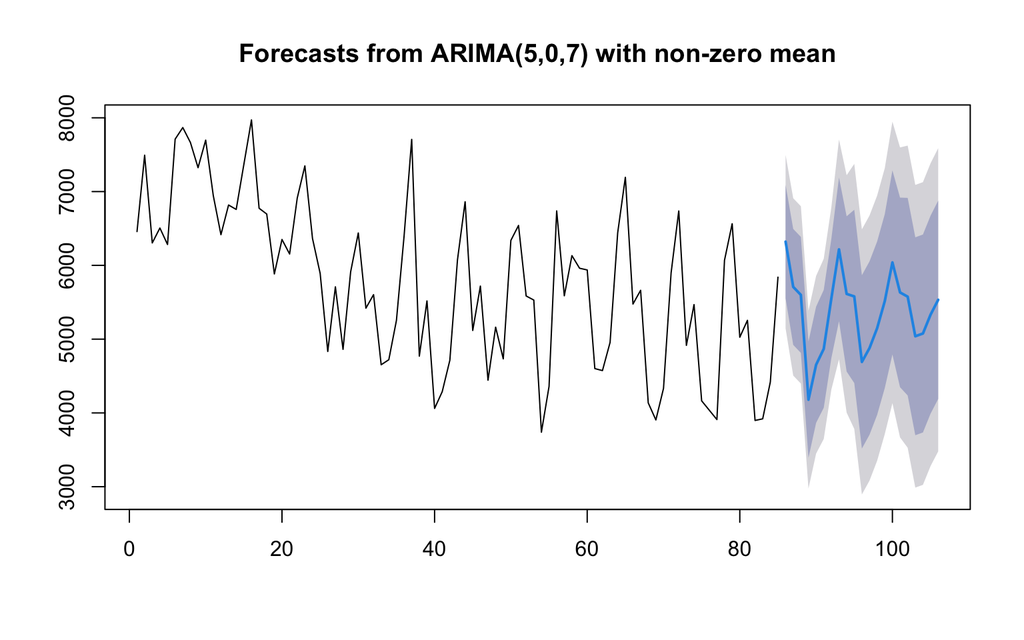

```r
data.ramalan.da <- ramalan.da$mean
plot(ramalan.da)
```

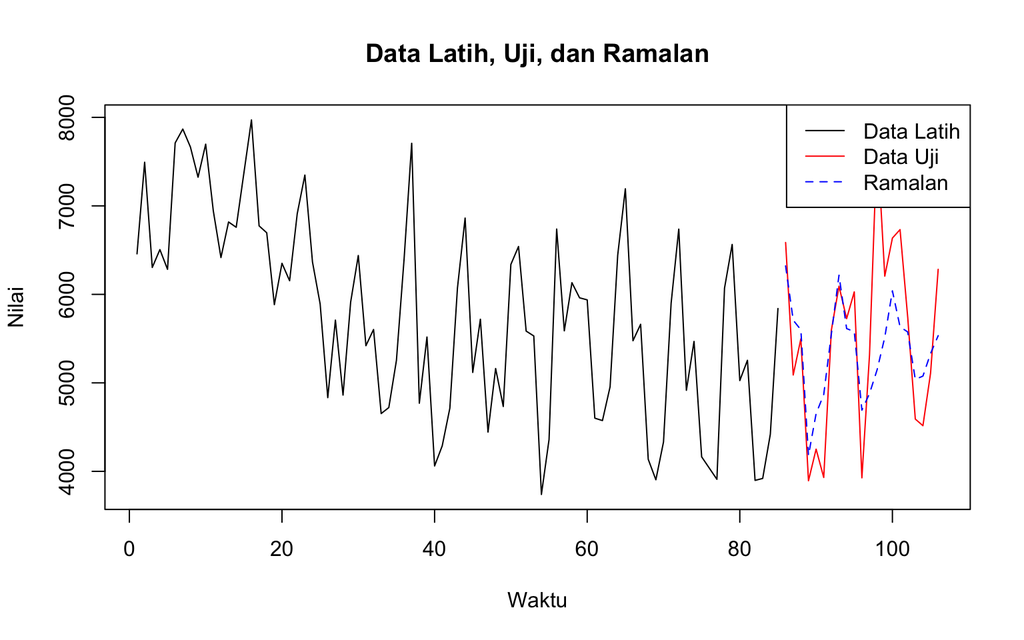

```r
plot(train.ts, xlim = c(1, length(train.ts) + length(test.ts)), ylim = range(c(train.ts, test.ts, data.ramalan.da)), col = "black", main = "Data Latih, Uji, dan Ramalan", ylab = "Nilai", xlab = "Waktu")
lines(seq(length(train.ts) + 1, length(train.ts) + length(test.ts)), test.ts, col = "red")
lines(seq(length(train.ts) + 1, length(train.ts) + length(test.ts)), data.ramalan.da, col = "blue", lty = 2)
legend("topright", legend = c("Data Latih", "Data Uji", "Ramalan"), col = c("black", "red", "blue"), lty = c(1, 1, 2))
```

```r
perbandingan.da <- matrix(data=c(head(test.ts, n=21), data.ramalan.da),
                          nrow = 21, ncol = 2)
colnames(perbandingan.da) <- c("Aktual", "Hasil Forecast")
perbandingan.da
```

```
##       Aktual Hasil Forecast
##  [1,]   6586       6321.611
##  [2,]   5089       5708.244
##  [3,]   5497       5599.869
##  [4,]   3894       4179.550
##  [5,]   4251       4652.855
##  [6,]   3931       4868.169
##  [7,]   5596       5552.850
##  [8,]   6092       6216.244
##  [9,]   5726       5613.225
## [10,]   6028       5579.182
## [11,]   3927       4691.494
## [12,]   5317       4879.385
## [13,]   7751       5149.205
## [14,]   6206       5515.501
## [15,]   6636       6039.735
## [16,]   6732       5633.277
## [17,]   5746       5575.680
## [18,]   4591       5039.099
## [19,]   4516       5076.550
## [20,]   5109       5331.749
## [21,]   6283       5533.433
```

```r
accuracy(ts(data.ramalan.da), head(test.ts, n=21))
```

```
##                ME     RMSE      MAE       MPE    MAPE     ACF1 Theil's U
## Test set 130.8139 773.2741 556.2257 0.2199367 10.0015 0.312509 0.6659393
```

# Kesimpulan